# My dinnertime habits and behaviours

Attempting to answer the questions I think about while eating my dinners.

## Introduction

This data was collected through a Google Forms survey investigating my personal dinner habits over a period of time. It includes dinner duration, phone usage while eating, vegetable intake, cuisine type, and cost of meals.

The aim of this visual data story is to explore whether my lifestyle behaviours **(such as phone use and vegetable intake)** are associated with differences in eating time and meal cost for my dinners. My ultimate goal here is to establish healthy dinner time habits.

## Does phone use affect how long I take to eat?

This graph shows the relationship between phone usage during dinner and the time taken to finish a meal. Individual responses are shown along with the mean time for each phone usage category.

This helps identify whether distractions like phone use are associated with longer eating times.

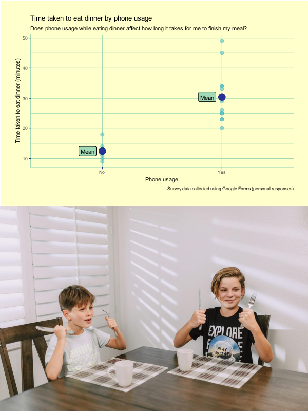

Scatterplot showing phone usage during dinner compared with the time taken to eat. It includes mean values for each phone usage group

From the graph, it seems that when I do use my phone, it takes me longer to finish my dinner, on average. All recorded times it took to eat my dinners for when I used my phone is higher than all the recorded times for when I did not use my phone, and the mean time for not using my phone while eating dinner is 17 minutes lower than the mean time for when I did use my phone.

From all the tiktoks and youtube videos I have watched, I know that being aware of what I eat and taking my time to eat and savour my food is what is best for my body. (It also helps minimise choking as a bonus!). As such, I believe that going on my phone while eating dinner to help slow down my eating is healthy for me, and without it I am a very fast eater and often do not get the luxury to savour my foods.

## How accurate am I when recording how long it takes for me to eat my dinners?

The graph compares my recorded eating time with my eating time calculated from two variables in my data. This was calculated by my start time **(Variable 1)** minus my end time **(Extracted from my timestamp)**. A trend line is included to help identify whether there is a relationship.

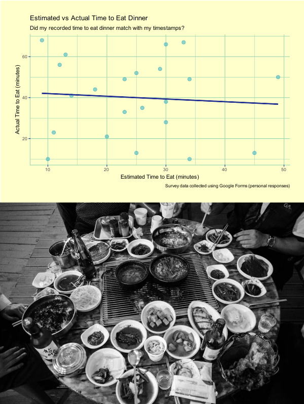

Scatterplot comparing recorded eating time versus calculated eating time.

There seems to be no correlation nor relationship between the two. It is probably because after my dinners I become lazy and sleepy, forgetting to record my data, leading to my dinner end times recorded through my timestamps to be very different from my actual dinner end times. Leading to there being no relationship between these two variables shown in the graph.

This seems to suggest that once my dinner is finished I am ready for bed. I get lazy and tired and cannot seem to do anything productive but get ready for bed. As such, this means I should get everything I need to get done such as schoolwork before I have my dinner. This way my productivity is high and my attention is focused on my work, rather than if I did it after dinner where I may be less energetic and focused.

## Is there obvious relationships between the amounts of vegetables I eat, the cuisines I eat and the cost of my meals?

This graph examines how meal cost varies across different levels of vegetable intake amounts and cuisine types. It uses box plots to show the distribution of costs within each group and subgroup.

I investigated this because I was curious as to whether a certain cuisine cost more than others, or if eating more vegetables cost more.

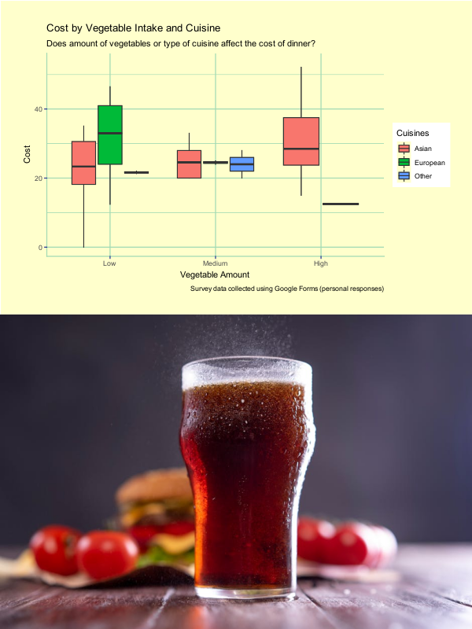

I really only have enough information to compare Asian and European cuisines, as these two are the cuisines I eat the most of. From the graph, my Asian dinners have more vegetables than European dinners, and European dinners cost more than Asian dinners.

As such, I should focus on eating more Asian cuisine dinners as these have the most vegetables and is cheaper than European cuisine dinners. Alternatively, to have a more healthy and varied diet, I could do more research into seeing vegetable dishes from other cuisines other than Asian, since that is where I am from.